# Project: TMDb Movie Data

- Introduction
- Data Wrangling
- Exploratory Data Analysis
- Conclusions

## Introduction

> **Short Summary of the project**: In this section of the report, the first task done is initialising the process in which the dataset of about 10000 movies is investigated, wherein insights about the data that is available. In our dataset, there are different attributes of the movies like genres, release data, revenue, budget, cast, director etc. Our dataset might also contain few empty entries in particular columns, if any of them would be really required to be cleaned we would clean them. I would like to eliminate the irrelevant entries in order to make our data analysis process easier and cleaner. I intend to solve two questions
> 1. How does movies vary according to the genre?
> 2. How does popularity affects the revenue of the movie?  
>    Lets begin by what are the packages needed to proceed further?

```python
# Here I am importing the packages that I intend to use
import pandas as pd
import numpy as np
import matplotlib.pyplot as plt
import seaborn as sns
# plt.style.available # I wish to see what kind of plot styes are available which I could make use of
```

## For my upcoming plots I would like to have style of **"ggplot"**

#### ggplot is wonderful for creating professinal looking plots, it gives out a very neat background with fluorescent colors

```python
plt.style.use('ggplot')
```

## Data Wrangling

> **What I do here?**: In this section of the report, I am going load in the data, check for cleanliness, and then trim and clean the dataset for analysis.

Since the columns like Cast, Director, homepage, tagline etc. are not really relevant for the investigation over the data we are trying to make, we would delete them.

### General Properties

#### The types of the data in each column are taken care implicitly since the data is imported as a DataFrame object.

##### Furthermore, I printed the expanse of the data we are going to analyse viz. the total number of entries, column names, first few entries of the DataFrame and then I cleaned the data whichever is not relevant for the current data analysis.

#### Importing CSV and Loading the data

```python
filename = 'tmdb-movies.csv'
movies_df = pd.read_csv(filename)
print len(movies_df) # To check what is the length of our dataset
```

```
10866
```

#### shape gives us the knowledge about the dimensions of the data we are going to analyse.

```python
movies_df.shape
```

```
(10866, 21)
```

here 10866 entries of movies are available having 21 attributes or columns.

> to get a glimpse of data that is available in our Dataframe. We are using head function. Here we would be able to see what our original dataset looks like. And after we clean our data for our required set of parameters, we would also have a look on what we are going to analyse!!

```python
movies_df.head()
```

|  | id | imdb_id | popularity | budget | revenue | original_title | cast | homepage | director | tagline | ... | overview | runtime | genres | production_companies | release_date | vote_count | vote_average | release_year | budget_adj | revenue_adj |
| --- | --- | --- | --- | --- | --- | --- | --- | --- | --- | --- | --- | --- | --- | --- | --- | --- | --- | --- | --- | --- | --- |
| 0 | 135397 | tt0369610 | 32.985763 | 150000000 | 1513528810 | Jurassic World | Chris Pratt\|Bryce Dallas Howard\|Irrfan Khan\|Vi... | http://www.jurassicworld.com/ | Colin Trevorrow | The park is open. | ... | Twenty-two years after the events of Jurassic ... | 124 | Action\|Adventure\|Science Fiction\|Thriller | Universal Studios\|Amblin Entertainment\|Legenda... | 6/9/15 | 5562 | 6.5 | 2015 | 1.379999e+08 | 1.392446e+09 |
| 1 | 76341 | tt1392190 | 28.419936 | 150000000 | 378436354 | Mad Max: Fury Road | Tom Hardy\|Charlize Theron\|Hugh Keays-Byrne\|Nic... | http://www.madmaxmovie.com/ | George Miller | What a Lovely Day. | ... | An apocalyptic story set in the furthest reach... | 120 | Action\|Adventure\|Science Fiction\|Thriller | Village Roadshow Pictures\|Kennedy Miller Produ... | 5/13/15 | 6185 | 7.1 | 2015 | 1.379999e+08 | 3.481613e+08 |
| 2 | 262500 | tt2908446 | 13.112507 | 110000000 | 295238201 | Insurgent | Shailene Woodley\|Theo James\|Kate Winslet\|Ansel... | http://www.thedivergentseries.movie/#insurgent | Robert Schwentke | One Choice Can Destroy You | ... | Beatrice Prior must confront her inner demons ... | 119 | Adventure\|Science Fiction\|Thriller | Summit Entertainment\|Mandeville Films\|Red Wago... | 3/18/15 | 2480 | 6.3 | 2015 | 1.012000e+08 | 2.716190e+08 |
| 3 | 140607 | tt2488496 | 11.173104 | 200000000 | 2068178225 | Star Wars: The Force Awakens | Harrison Ford\|Mark Hamill\|Carrie Fisher\|Adam D... | http://www.starwars.com/films/star-wars-episod... | J.J. Abrams | Every generation has a story. | ... | Thirty years after defeating the Galactic Empi... | 136 | Action\|Adventure\|Science Fiction\|Fantasy | Lucasfilm\|Truenorth Productions\|Bad Robot | 12/15/15 | 5292 | 7.5 | 2015 | 1.839999e+08 | 1.902723e+09 |
| 4 | 168259 | tt2820852 | 9.335014 | 190000000 | 1506249360 | Furious 7 | Vin Diesel\|Paul Walker\|Jason Statham\|Michelle ... | http://www.furious7.com/ | James Wan | Vengeance Hits Home | ... | Deckard Shaw seeks revenge against Dominic Tor... | 137 | Action\|Crime\|Thriller | Universal Pictures\|Original Film\|Media Rights ... | 4/1/15 | 2947 | 7.3 | 2015 | 1.747999e+08 | 1.385749e+09 |

5 rows × 21 columns

## Data Cleaning

### Here we look at which columns contain major number of null entries.

After discussing the structure of the data and any problems that need to be cleaned, we are going perform those cleaning steps in the second part of this section.

Here before cleaning we look at our data for how many null entries does it have? It gives us a clearer idea of what needs to be used and what needs to be removed from our dataset!

```python
movies_df.isnull().sum()
```

```
id                         0
imdb_id                   10
popularity                 0
budget                     0
revenue                    0
original_title             0
cast                      76
homepage                7930
director                  44
tagline                 2824
keywords                1493
overview                   4
runtime                    0
genres                    23
production_companies    1030
release_date               0
vote_count                 0
vote_average               0
release_year               0
budget_adj                 0
revenue_adj                0
dtype: int64
```

Since we are going to process genres, any empty value wouldn't be useful. So, we are going to fix the problem of having empty genres.

```python
# Lets replace all the empty string with NaN since Pandas won't recognise empty strings.
movies_df['genres'].replace('', np.nan, inplace=True)
```

```python
# Here we're checking for the empty values.
# Wherever there are empty values we would take a count of them
print (movies_df['genres'].isnull().sum())
```

```
23
```

So we can clearly see here the number of empty entries in genres!

# Since, we are not interested in any movie having no genre and 23 is much smaller as compared to our set total 10k, we would drop the entries

Removing such a small number of data entries won't have a very large impact over our visualtisations!

```python
movies_df.dropna(subset=['genres'], inplace=True)
movies_df['genres'].isnull().sum() # To make a confirmation that all empty colunms are eliminated
```

```
0
```

So, we get a confirmation here that no empty values are remaining in our dataframe

### Since we won't need few columns for analysis, here we are removing them!

```python
##### Here we won't be analyzing few columns so I would delete them from our DataFrame
columns_to_be_deleted = ['homepage','imdb_id','production_companies','tagline','overview','cast','director','keywords']
movies_df.drop(columns_to_be_deleted,axis=1,inplace=True)
```

### now lets have a look at what do we have in our hand right now

```python
movies_df.head()
```

|  | id | popularity | budget | revenue | original_title | runtime | genres | release_date | vote_count | vote_average | release_year | budget_adj | revenue_adj |
| --- | --- | --- | --- | --- | --- | --- | --- | --- | --- | --- | --- | --- | --- |
| 0 | 135397 | 32.985763 | 150000000 | 1513528810 | Jurassic World | 124 | Action\|Adventure\|Science Fiction\|Thriller | 6/9/15 | 5562 | 6.5 | 2015 | 1.379999e+08 | 1.392446e+09 |
| 1 | 76341 | 28.419936 | 150000000 | 378436354 | Mad Max: Fury Road | 120 | Action\|Adventure\|Science Fiction\|Thriller | 5/13/15 | 6185 | 7.1 | 2015 | 1.379999e+08 | 3.481613e+08 |
| 2 | 262500 | 13.112507 | 110000000 | 295238201 | Insurgent | 119 | Adventure\|Science Fiction\|Thriller | 3/18/15 | 2480 | 6.3 | 2015 | 1.012000e+08 | 2.716190e+08 |
| 3 | 140607 | 11.173104 | 200000000 | 2068178225 | Star Wars: The Force Awakens | 136 | Action\|Adventure\|Science Fiction\|Fantasy | 12/15/15 | 5292 | 7.5 | 2015 | 1.839999e+08 | 1.902723e+09 |
| 4 | 168259 | 9.335014 | 190000000 | 1506249360 | Furious 7 | 137 | Action\|Crime\|Thriller | 4/1/15 | 2947 | 7.3 | 2015 | 1.747999e+08 | 1.385749e+09 |

```python
movies_df.info() # To understand how many columns are there and what datatype do they hold
```

```
<class 'pandas.core.frame.DataFrame'>
Int64Index: 10843 entries, 0 to 10865
Data columns (total 13 columns):
id                10843 non-null int64
popularity        10843 non-null float64
budget            10843 non-null int64
revenue           10843 non-null int64
original_title    10843 non-null object
runtime           10843 non-null int64
genres            10843 non-null object
release_date      10843 non-null object
vote_count        10843 non-null int64
vote_average      10843 non-null float64
release_year      10843 non-null int64
budget_adj        10843 non-null float64
revenue_adj       10843 non-null float64
dtypes: float64(4), int64(6), object(3)
memory usage: 1.2+ MB
```

```python
movies_df['revenue'].describe() # Get the variations in the revenue data.
```

```
count    1.084300e+04
mean     3.990779e+07
std      1.171131e+08
min      0.000000e+00
25%      0.000000e+00
50%      0.000000e+00
75%      2.413675e+07
max      2.781506e+09
Name: revenue, dtype: float64
```

We used **describe** function here to see what is the range of the revenue column, because our analysis would majorly depend upon this

## Exploratory Data Analysis

> **Insights**: Now that I've trimmed and cleaned my data, I am going to Compute statistics and create visualizations with the goal of addressing the research questions that were posed in the Introduction section.

### My First Question : How does movies vary according to the genre?

#### Before we have already got the datatype of the Genre column fixed up by removing the null entries, here we would parse it so that we could plot some graphs over the data!

##### Since it is having values separated by | and is not having a python compatible column entries

we are going to split the genres and also would categorize over how many movies belong to a genre.

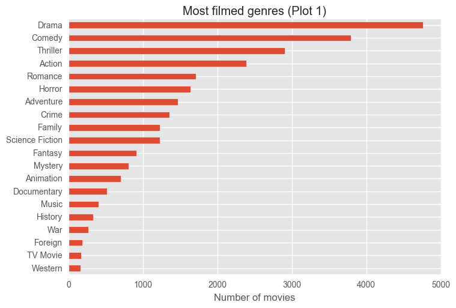

```python
# Get all genres
all_genres = movies_df['genres'].str.cat(sep='|') # sep('|') <-- is our separator
all_genres = pd.Series(all_genres.split('|'))

# Count the genres
count = all_genres.value_counts(ascending=True)

# Plot
ax = count.plot.barh()
ax.set(title='Most filmed genres (Plot 1)',
       xlabel = 'Number of movies')
plt.show()
```

### Question 2 : How does revenue varies along the popularity?

> Here I wish to see if the popular movies really make good money?

here we are going to plot a scatter plot which would give us insights to data.

[figure not shown]

```python
ax = movies_df.plot.scatter(x="revenue", y="popularity",alpha=0.5,s=75)
ax.set(title='Revenue variation with popularity (Plot 2)',
       xlabel='Popularity',
       ylabel='Revenue')

plt.show()
```

### Now we are going to plot a regplot so that we can also get to understand one thing : how these variables are related to each other?

> Does increase in the popularity really cause increase in revenue?

[figure not shown]

```python
x = movies_df['revenue']
y = movies_df['popularity']
plt.scatter(x, y, alpha=0.5, s=75)
m, b = np.polyfit(x, y, 1)
plt.plot(x, y, '.')
plt.plot(x, m*x + b, '-', color='r')
plt.title('Revenue variation with popularity (Plot 3)')
plt.xlabel('Popularity')
plt.ylabel('Revenue')
plt.show()
```

**This plot was made using scatter plot and explicitly having a regression line** From this plot we can see how our revenue is tending to increase along with the popularity at the same time we can also see that there are few outliers.

> Although it is observed that the revenue tends to increase, still, there are few movies having high popularity than that of others couldn't make a lot of money!

#### Here I plotted a new graph again, with regplot which automatically takes care of regression line.

Here is was also observed that the results of the above plot viz (Plot 3) are repeated, also we could see that the regression line generated was also proving the fact that as the popularity increases, the revenue also increases.

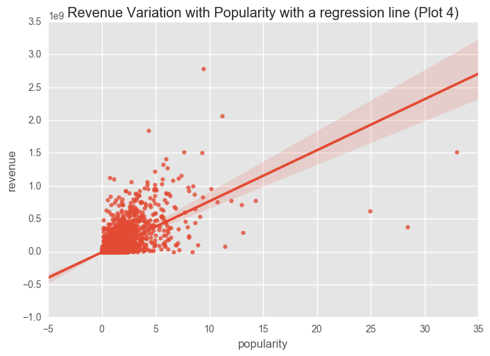

```python
sns.regplot(x="popularity", y="revenue", data=movies_df,fit_reg=True)
plt.title("Revenue Variation with Popularity with a regression line (Plot 4)")
plt.show()
```

Hence we can clearly see that the Revenue rises as popularity is rising however, we can also see some errors which also let us know that correlation doesn't imply causation.

# Now can we also know how many movies were actually profitable out of all the movies?

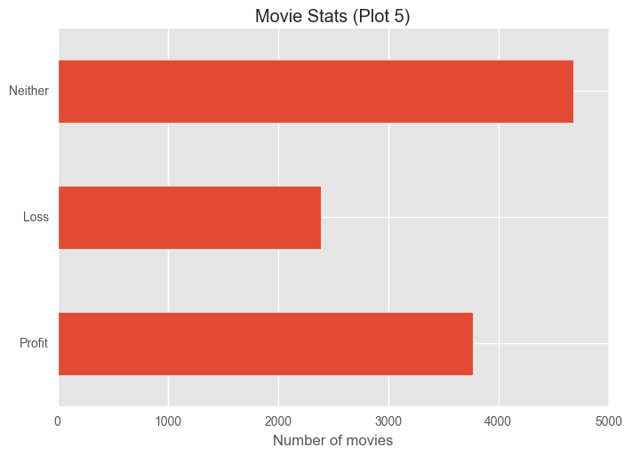

```python
diff_bug_rev = movies_df['revenue'] - movies_df['budget']
profit = sum(diff_bug_rev > 0)
loss = sum(diff_bug_rev < 0)
zero = sum(diff_bug_rev == 0)
profit_loss = pd.Series([profit,loss,zero],index=["Profit","Loss","Neither"])
ax = profit_loss.plot.barh()
ax.set(title='Movie Stats (Plot 5)',
       xlabel = 'Number of movies')
plt.show()
```

Which would also be clear to us after having a look at the pie chart

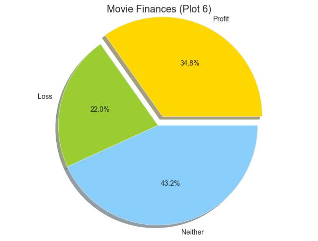

```python
#profit_loss = pd.Series([profit,loss,zero],index=["Profit","Loss","Neither"])
labels = 'Profit', 'Loss', 'Neither'
colors = ['gold', 'yellowgreen', 'lightskyblue']
explode = (0.1, 0, 0)  # explode 1st slice

# Plot
plt.pie(profit_loss, explode=explode, labels=labels, colors=colors,
        autopct='%1.1f%%', shadow=True, startangle=0)
plt.title("Movie Finances (Plot 6)")
plt.axis('equal')
plt.show()
```

# Limitations

There were few limitations to the analysis based on the given data.

> 1. First Since we had already dropped out many columns out of our analysis since they were irrelevant for our analysis.
> 2. Many of the columns were simply either strings or urls or some basic info which we could have got from genres. Also many columns had a large number of empty entries which is not a good sign for conducting proper data analysis over it.
> 3. Inconsistency in the column of Genres, as there were multiple genres for a single movie, also in some cases there were no entries which we had cleared out in the beginning.
> 4. In the column of popularity the range was too large to carry our analysis on. Ex. Max value for range came out to be 32 and min was 0. Also, max value was really very far awar from the mean value of 1.
> 5. Popularity was not defined on a proper scale and it was dependent on many factors of how many people voted for it on one day, etc.
> 6. The two columns of revenue_adj and budget_adj were not so clear about what the TMDb wanted to convey from it and there was not a lot of description given for it either over their website.

# Other Variables

1. We could have also looked at vote count for a movie and average ratings for a movie to understand how better it was.
2. Combining the above mentioned variable with revenue we could draw conclusions also over how did revenue vary with votes casted.
3. Release_date variable would also help us group the movies according to our needs and we can also classify what genre was popular in a particular year?

## Conclusions

> **Question 1**: **How does movies vary according to the genre?** Here we could visualize the data of the movies, how many movies belonged to each of the genres listed in their columns. Here it was an observational question so there is neither **causation nor correlation**. Its just for our information to know which genre has most number of movies.

> **Question 2**: **How does revenue vary with popularity?** Here we could see how popularity affected the revenue of the movie (Plot 2, 3 and 4). It was visible from our (Plot 3) it's not really true that all the movies which are popular made good money, and also, its not true that movies which were not popular were bad at revenue. It was visible how the movies which were not really very popular also generated good amount of revenue. However, we could see that as the popularity increased the revenue tends increase as well. So, we can conclude that **Correlation doesn't imply causation**

### If there are few movies which are having high popularity needn't imply they would fetch good amount of money and vice versa.

> At the end I had plotted a bar graph (Plot 5) and a pie chart (Plot 6) to depict how many of all these movies were actually profitable and we could see that only 34% of all the movies that were there could make profits! This point could be very important for someone who really needs to understand how movies really work out financially!